# R Notebook

Now scraped, so it can be updated automatically instead:

```r
# formularydatascraped[[1]] all the drugs
# formularydatascraped[[2]] drugs + titles (incl. non-formulary)
# formularydatascraped[[5]] all the titles

formularydatascraped <- list()
formularydatascraped[[1]] <- xml2::read_html("http://www.taysideformulary.scot.nhs.uk/chaptersSubDetails.asp?FormularySectionID=5&SubSectionRef=05&SubSectionID=A100&FC=1") %>% # formularydatascraped[[1]] is all the drugs (antimicrobials)
  html_nodes(css = ".boldDrug") %>%
  html_text() %>%
  as.character() %>%
  stringr::str_replace("\r\n\t  ", replacement = "")
```

There are 184 antibiotics listed in NHS Tayside formulary.

16 of these are non-formulary.

There are a handful of [hierachy methods](https://observablehq.com/collection/@d3/d3-hierarchy) for D3. I’ve already demonstrated the [Force-directed trees](https://observablehq.com/@d3/force-directed-tree), including the [dragging effect](https://bl.ocks.org/mbostock/ad70335eeef6d167bc36fd3c04378048).

I’ve also already tried a variant of [Tidy Tree](https://observablehq.com/@d3/tidy-tree?collection=@d3/d3-hierarchy) in other methods. I could reformat my tidy trees a little to present it as a [Radial Tidy Tree](https://observablehq.com/@d3/radial-tidy-tree?collection=@d3/d3-hierarchy) or [Radial Dendrogram.](https://observablehq.com/@d3/radial-dendrogram?collection=@d3/d3-hierarchy)

In order to do this though, I’ll reformat the data to work directly through D3. Rather than just an R wrapper.

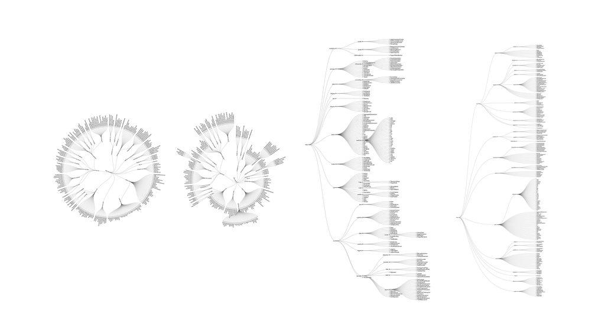

[1, Radial Dendrogram](https://observablehq.com/@d3/radial-dendrogram?collection=@d3/d3-hierarchy), [2, Radial Tidy Tree](https://observablehq.com/@d3/radial-tidy-tree?collection=@d3/d3-hierarchy), [3, Tidy Tree,](https://observablehq.com/@d3/tidy-tree?collection=@d3/d3-hierarchy) [4, Cluster Dendrogram.](https://observablehq.com/@d3/cluster-dendrogram?collection=@d3/d3-hierarchy)

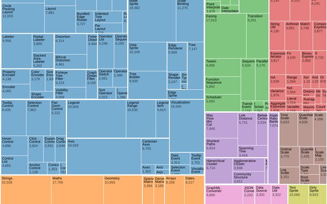

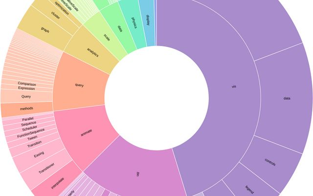

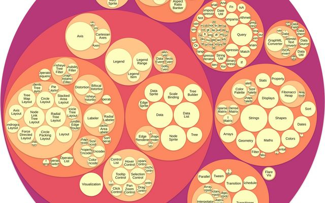

I could also use a [1, Treemap](https://observablehq.com/@d3/treemap?collection=@d3/d3-hierarchy), a [2, (Zoomable) Sunburst](https://observablehq.com/@d3/zoomable-sunburst?collection=@d3/d3-hierarchy), a [Circle Packing Diagram,](https://observablehq.com/@d3/circle-packing-monochrome?collection=@d3/d3-hierarchy) [3, in colour.](https://observablehq.com/@d3/circle-packing?collection=@d3/d3-hierarchy)

#### Reformating the data

I have to reformat my data to match flare-2.json.

More:

Combining National information:

- [Scottish Medicines Consortium](https://www.scottishmedicines.org.uk)
- [BNF Interactions](https://bnf.nice.org.uk/drug/)
- [The Scottish Antimicrobial Prescribing Group](https://www.sapg.scot)

To give functions using this new data I’ll need to graph it using the [D3 Graph Gallery.](https://www.d3-graph-gallery.com/dendrogram.html)

- [D3 Force](https://github.com/d3/d3-force)
- [Most basic radial dendrogram in d3.js](https://www.d3-graph-gallery.com/graph/dendrogram_radial_basic.html)
- [r2d3](https://rstudio.github.io/r2d3/)